# TCGA-COAD Survival & Molecular Subtype Analyses for the CD55-Associated Immune-Regulatory (IRC) Signature

## 2 Kaplan–Meier Survival Analysis Based on Gene or Gene-Set Expression

This section implements a flexible survival analysis framework that links tumor gene expression to patient outcome in the TCGA colorectal cancer cohort. The provided functions compute per-patient expression scores either for a single gene (e.g., CD55) or for a multi-gene signature by averaging normalized logCPM values across the specified gene set. These patient-level scores are then integrated with the clinical survival table (containing overall survival time and event status) and used to stratify samples into high- and low-expression groups based on either a median split or upper/lower quantiles (e.g., top and bottom 20% or 30%). Kaplan–Meier curves with log-rank p-values and risk tables are generated to visualize and statistically assess the association between expression level and overall survival, enabling direct evaluation of prognostic effects of individual genes or coordinated transcriptional programs such as the CD55-associated immune-regulatory signature.

Function: - accepts either a single gene (e.g., “CD55”) or a gene set (character vector), - computes an expression/score per patient (TCGA 12-char ID), - merges with your surv_df (must contain patient_id, time, event), - splits samples into High/Low (median or top/bottom X%), - plots the Kaplan–Meier curve with risk table.

```r
library(dplyr)
library(SummarizedExperiment)
library(survival)
library(survminer)

## ------------------------------------------------------------
## Helper 1: compute signature score per sample
## ------------------------------------------------------------
score_from_signature <- function(exp_se,
                                 logCPM,
                                 gene_set,
                                 score_name = "signature_score",
                                 symbol_col = NULL) {
  rd <- as.data.frame(rowData(exp_se))

  # Auto-detect symbol column if not provided
  if (is.null(symbol_col)) {
    candidate_cols <- c("gene_name", "external_gene_name",
                        "symbol", "hgnc_symbol", "GeneSymbol")
    symbol_col <- intersect(candidate_cols, colnames(rd))[1]
    if (is.na(symbol_col)) {
      stop("Could not detect a gene symbol column in rowData(exp_se). ",
           "Please provide 'symbol_col' explicitly.")
    }
  } else if (!symbol_col %in% colnames(rd)) {
    stop("Provided symbol_col '", symbol_col,
         "' not found in rowData(exp_se).")
  }

  # Map gene symbols to row indices
  idx <- which(rd[[symbol_col]] %in% gene_set)
  if (length(idx) == 0) {
    stop("None of the genes in gene_set were found in rowData(exp_se)[['",
         symbol_col, "']].")
  }

  found_genes <- rd[[symbol_col]][idx]
  missing_genes <- setdiff(gene_set, found_genes)
  if (length(missing_genes) > 0) {
    message("Warning: the following genes were not found and will be ignored: ",
            paste(missing_genes, collapse = ", "))
  }

  # Compute mean logCPM across signature genes
  sig_score <- colMeans(
    logCPM[idx, , drop = FALSE],
    na.rm = TRUE
  )

  # Per-patient table
  df <- data.frame(
    patient_id = substr(names(sig_score), 1, 12),
    score      = as.numeric(sig_score),
    stringsAsFactors = FALSE
  )
  colnames(df)[2] <- score_name

  return(list(
    score_df    = df,
    symbol_col  = symbol_col,
    idx         = idx,
    found_genes = found_genes
  ))
}

## ------------------------------------------------------------
## Helper 2: Kaplan–Meier from a signature score
##   split = "20", "30", or "median"
## ------------------------------------------------------------
km_from_signature <- function(exp_se,
                              logCPM,
                              surv_df,
                              gene_set,
                              split      = c("20", "30", "median"),
                              score_name = "signature_score",
                              symbol_col = NULL,
                              legend_title = "Signature") {
  split <- match.arg(split)

  ## 1) Compute signature score
  sig_res <- score_from_signature(
    exp_se     = exp_se,
    logCPM     = logCPM,
    gene_set   = gene_set,
    score_name = score_name,
    symbol_col = symbol_col
  )

  score_df <- sig_res$score_df
  colnames(score_df)[2] <- "score"

  ## 2) Merge with survival table
  km_df <- surv_df %>%
    inner_join(score_df, by = "patient_id") %>%
    filter(!is.na(score), !is.na(time), !is.na(event))

  ## 3) Define grouping based on split mode
  if (split %in% c("20", "30")) {
    p_low  <- as.numeric(split) / 100
    p_high <- 1 - p_low

    qs <- quantile(km_df$score, probs = c(p_low, p_high), na.rm = TRUE)
    low_cut  <- qs[1]
    high_cut <- qs[2]

    km_df_sub <- km_df %>%
      mutate(
        group = case_when(
          score <= low_cut  ~ "Low",
          score >= high_cut ~ "High",
          TRUE              ~ NA_character_
        )
      ) %>%
      filter(!is.na(group))

    legend_labs <- c(
      paste0("High ", split, "%"),
      paste0("Low ",  split, "%")
    )

  } else if (split == "median") {
    med <- median(km_df$score, na.rm = TRUE)

    km_df_sub <- km_df %>%
      mutate(
        group = ifelse(score >= med, "High", "Low")
      )

    legend_labs <- c("High (≥ median)", "Low (< median)")
  }

  km_df_sub$group <- factor(km_df_sub$group, levels = c("High", "Low"))

  ## 4) Fit KM
  fit <- survfit(
    Surv(time, event) ~ group,
    data = km_df_sub
  )

  ## 5) Plot
  p <- ggsurvplot(
    fit,
    data         = km_df_sub,
    pval         = TRUE,
    risk.table   = TRUE,
    legend.title = legend_title,
    legend.labs  = legend_labs,
    xlab         = "Days",
    ylab         = "Overall survival",
    palette      = c("#D64545", "#4E79A7"),
    ggtheme      = theme_classic(base_size = 14)
  )

  return(list(
    fit        = fit,
    data       = km_df_sub,
    plot       = p,
    score_df   = score_df,
    symbol_col = sig_res$symbol_col,
    found_genes = sig_res$found_genes
  ))
}
```

## 3 Kaplan–Meier Survival Analysis Based on the Immune-Regulatory CD55-Associated (IRC) Gene Signature

In this section, an immune-regulatory epithelial gene signature (IRC), centered on CD55 and associated interferon, complement-regulatory, barrier, and stromal interaction programs, is defined and evaluated for its prognostic relevance in human colorectal cancer. The curated gene set is summarized into a single per-patient expression score by averaging normalized logCPM values across all signature genes. Patients are then stratified into high- and low-IRC groups using an extreme-quantile approach (top and bottom 20% of the score distribution), thereby enriching for tumors with strongly activated versus weakly expressed IRC programs while excluding intermediate cases. Kaplan–Meier survival curves with log-rank statistics and risk tables are generated to assess the association between IRC activity and overall survival, enabling a quantitative evaluation of whether activation of the CD55-linked immune-regulatory epithelial state is linked to adverse clinical outcome.

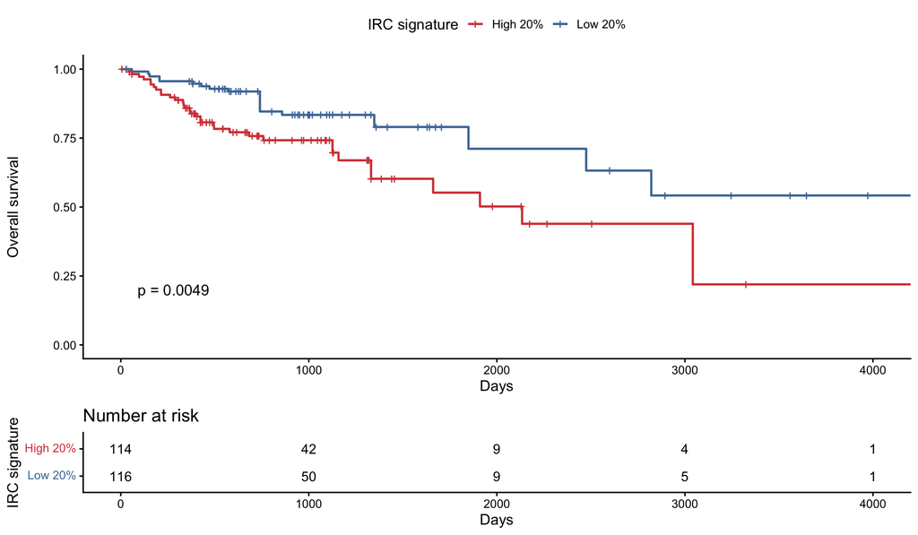

```r
irc_genes <- c(
  "IRF7", "HSPA1A", "RGS16", "SNAI1", "SERPINH1", "ACE", "EGFL7", "HBA2", "HBA1",
  "ADAMTS4", "MUSTN1", "SERPINE1", "HSPA1B", "LY6G6C", "FABP4", "ST6GALNAC6",
  "B3GALT5", "IRGM", "ICAM2", "CD55", "ENG", "RAB3IL1", "ANXA8", "SCN1B",
  "RTL8A", "SPARCL1", "RTL8B", "MFNG", "GIMAP1", "GPX3", "COL18A1", "SEMA6B",
  "ACTA2", "FCGR1A", "TNFAIP8L2", "FKBP10", "SH3TC1", "TPM2", "ESAM", "TGFB1I1",
  "GRAP", "BCR", "HSPG2", "ITGB7", "FHL1", "HMGN3", "CXCL12", "EBF1", "S100A4",
  "IGFBP7", "IFI27L2", "THBS4", "DMD", "RAMP2", "RASGRP3", "TP53I11", "PTP4A3",
  "SPARC", "EHD2", "NHSL2", "S100A16", "GJB3", "NT5DC2"
)


## 20% tails
res_irc_20 <- km_from_signature(
  exp_se       = exp_se,
  logCPM       = logCPM,
  surv_df      = surv_df,
  gene_set     = irc_genes,
  split        = "20",
  score_name   = "irc_score",
  legend_title = "IRC signature"
)

res_irc_20$plot  # prints the KM
```